# Homework 6 STAT 488

Brandon Ristoff

04/13/2020

```r
knitr::opts_chunk$set(echo = TRUE)
```

## Describing the Data

```r
library(readr)
library(janitor)
library(mvtnorm)
library(MASS)
library(dplyr)
```

```r
library(corrplot)
library(readxl)
library(lubridate)
library(reshape2)
school <- read_csv("ill_school_data.csv")
str(school)
```

```
## Classes 'spec_tbl_df', 'tbl_df', 'tbl' and 'data.frame': 500 obs. of  60 variables:
##  $ Country                         : chr  "USA" "USA" "USA" "USA" ...
##  $ Region                          : chr  "IL" "IL" "IL" "IL" ...
##  $ DataYear                        : num  2016 2014 2015 2019 2016 ...
##  $ ClassGrade                      : num  12 12 10 10 9 12 12 12 10 10 ...
##  $ Gender                          : chr  "Male" "Male" "Female" "Female" ...
##  $ Ageyears                        : num  17 17 17 16 15 17 17 16 15 15 ...
##  $ Handed                          : chr  "Right-Handed" "Right-Handed" "Right-Handed" "Right-Handed" ...
##  $ Height_cm                       : chr  "182" "185.6" "98" "160" ...
##  $ Footlength_cm                   : chr  "24" "27" "20" "23.8" ...
##  $ Armspan_cm                      : chr  "186" "200" "120" "163" ...
##  $ Languages_spoken                : num  1.5 1 2 2 2 NA 2 1 4 2 ...
##  $ Travel_to_School                : chr  "Car" "Car" "Car" "Car" ...
##  $ Travel_time_to_School           : chr  "15" "2" "15" "7" ...
##  $ Reaction_time                   : num  0.384 0.33 5 0.513 0.68 0.349 0.443 0.33 0.355 0.337 ...
##  $ Score_in_memory_game            : chr  "39" "38" "66" "44" ...
##  $ Favourite_physical_activity     : chr  "Swimming" "Football (American)" "Swimming" "Soccer" ...
##  $ Importance_reducing_pollution   : num  900 800 0 1000 10 5000 900 850 1000 1000 ...
##  $ Importance_recycling_rubbish    : num  700 800 0 999 500 5000 800 850 1000 1000 ...
##  $ Importance_conserving_water     : num  1000 500 0 500 1000 5000 750 925 1000 1000 ...
##  $ Importance_saving_energy        : num  1000 700 0 1000 1000 9000 740 925 1000 1000 ...
##  $ Importance_owning_computer      : num  700 1000 0 20 1 7500 500 610 50 219 ...
##  $ Importance_Internet_access      : num  700 500 0 1000 700 7500 550 610 50 401 ...
##  $ Left_Footlength_cm              : chr  "24" "27" "20" "23.8" ...
##  $ Longer_foot                     : chr  "Same length" "Same length" "Same length" "Same length" ...
##  $ Index_Fingerlength_mm           : chr  "72" "85" "7.5" "60" ...
##  $ Ring_Fingerlength_mm            : chr  "72" "79" "7" "65" ...
##  $ Longer_Finger_Lefthand          : chr  "Same length" "Index finger" "Index finger" "Ring finger" ...
##  $ Birth_month                     : chr  "May" "April" "June" "May" ...
##  $ Favorite_Season                 : chr  "Summer" "Summer" "Fall" "Summer" ...
##  $ Allergies                       : chr  "Yes" "No" NA "No" ...
##  $ Vegetarian                      : chr  "No" "No" "Yes" "No" ...
##  $ Favorite_Food                   : chr  "Meat" "Seafood" "Fruit" "Seafood" ...
##  $ Beverage                        : chr  "Water" "Water" "Water" "Water" ...
##  $ Favorite_School_Subject         : chr  "Mathematics and statistics" "Other" "Physical education" "Physical education" ...
##  $ Sleep_Hours_Schoolnight         : chr  "9" "5" "4.5" "8" ...
##  $ Sleep_Hours_Non_Schoolnight     : chr  "9.5" "9" "9" "6" ...
##  $ Home_Occupants                  : chr  "3" "3" "3" "6" ...
##  $ Home_Internet_Access            : chr  "Yes - other" "Yes - broadband connection" "Yes - broadband connection" "Yes - other" ...
##  $ Communication_With_Friends      : chr  "Cell phone" "Cell phone" "Cell phone" "Internet chat or instant messaging" ...
```

[output cut: 69 more lines]

```
##   ..   Video_Games_Hours = col_character(),
##   ..   Social_Websites_Hours = col_character(),
##   ..   Texting_Messaging_Hours = col_character(),
##   ..   Computer_Use_Hours = col_character(),
##   ..   Watching_TV_Hours = col_character(),
##   ..   Paid_Work_Hours = col_character(),
##   ..   Work_At_Home_Hours = col_character(),
##   ..   Schoolwork_Pressure = col_character(),
##   ..   Planned_Education_Level = col_character(),
##   ..   Favorite_Music = col_character(),
##   ..   Superpower = col_character(),
##   ..   Preferred_Status = col_character(),
##   ..   Role_Model_Type = col_character(),
##   ..   Charity_Donation = col_character()
##   .. )
```

```r
school2 <- school

rowSums(is.na(school))
```

```
##   [1] 18  0  1  0  0  7  1  0  1  2  0  6  0  0  8  0 48  0  0  0  0 51  0
##  [24]  0  3  0  0  0  0  0 10 19  0  0  0  0  0 43 44  1  0  0 16  0  0  0
##  [47]  0  0  8  0  0  3  0  0  1  0 52  0  0  0 16  0  0  1  0  0  0 54 27
##  [70] 46 36  0  1  1  0  1  0  0  0  1  0  0  0  0  0 36  0  0  0 15 11 25
##  [93] 54  6  6  6  0  0  0  0  0  0  0  1  0  1  0 18  0  0  2  1  0  0 15
## [116]  0  0  0  3  0  0  0  1  0 51  0 23  3 51  0  0  0 54  0  0 25  0  0
## [139]  0  0  0 25  0  0 34  0  0 37 18  0  1 44  2  0  1  0  0  0  0  0  0
## [162]  0  0  1  0  0  0  6 47  3  0  0  1  1  0  0 36  0  0  0  0  1  2  1
## [185]  1  0  1 42  0  0  0 21  0  0 18  0  0  0  0  0 43 49  0  1  1  0  0
## [208]  0 43  0  0  0  1  0  0  1 12  0 52  0 56  0  0  0 36  1 47  0 15  0
## [231]  0  0  0  0  0 43  0  0  0  0  1  0  0  7  0  0  0 18  1  3  7  0 17
## [254] 31  0  0  0  0 12  0  0  1  0  0  1  1  0 38  1  0  0  0  0  0  1  1
## [277]  0  2  9  1  0  0  0  0  1  0  0 43 18  1  0  0  2  0  0 19  0  0  0
## [300]  1  0  0  1  0  0 18  0 13  0  0  0  1  0 18  0  0 14  0  0  8  0 19
## [323] 43  0  0  0  0 43  0  0  0  0  1  0 15  0  0  0  0  0  0  0  0  1  0
## [346]  1  0  0 43  0  1  0  1  0  0 42  0  0 55 23  0 43  0  0  0  0  0  0
## [369]  0  0  0  0  7 53  5  0  0  0 16  0  0  0  1 27  2  0  0  0  0  0  0
## [392] 54 36  0  1 51  0 27  0  0 54  0  0  0  1  0 37  0  0  0  0  0  0  0
## [415]  1  0  0  0  6  0  1  0  0  1  1  0  0  0  0  0  0  0  0 51  7  0  0
## [438]  0 53  0  0  0  0  0 38  3  0  0  0  0  0  0  0  0 36 25  0  0  0  0
## [461]  0  1  0  0  0  0  0  0  0 44  0  0  0  0  3  0  0  0  0  0  0  0  0
## [484]  0  0  9  1  1 52  2  0  0  0  0  0 32  0  0 13  1
```

```r
sum(rowSums(is.na(school))>50)
```

```
## [1] 17
```

```r
colSums(is.na(school))
```

```
##                          Country                           Region
##                                0                                0
##                         DataYear                       ClassGrade
##                                0                                0
##                           Gender                         Ageyears
##                                5                                4
##                           Handed                        Height_cm
##                               12                               29
##                    Footlength_cm                       Armspan_cm
##                               34                               49
##                 Languages_spoken                 Travel_to_School
##                               22                               21
##            Travel_time_to_School                    Reaction_time
##                               19                               32
##             Score_in_memory_game      Favourite_physical_activity
##                               35                               28
##    Importance_reducing_pollution     Importance_recycling_rubbish
##                               38                               47
##      Importance_conserving_water         Importance_saving_energy
##                               49                               50
##       Importance_owning_computer       Importance_Internet_access
##                               50                               51
##               Left_Footlength_cm                      Longer_foot
##                               63                               59
##            Index_Fingerlength_mm             Ring_Fingerlength_mm
##                               73                               74
##           Longer_Finger_Lefthand                      Birth_month
##                               58                               50
##                  Favorite_Season                        Allergies
##                               50                               52
##                       Vegetarian                    Favorite_Food
##                               52                               51
##                         Beverage          Favorite_School_Subject
##                               52                               53
##          Sleep_Hours_Schoolnight      Sleep_Hours_Non_Schoolnight
##                               49                               52
##                   Home_Occupants             Home_Internet_Access
##                               51                               55
##       Communication_With_Friends     Text_Messages_Sent_Yesterday
##                               61                               54
## Text_Messages_Received_Yesterday   Hanging_Out_With_Friends_Hours
##                               56                               58
##           Talking_On_Phone_Hours             Doing_Homework_Hours
##                               70                               69
##   Doing_Things_With_Family_Hours         Outdoor_Activities_Hours
##                               71                               75
##                Video_Games_Hours            Social_Websites_Hours
##                               78                               79
##          Texting_Messaging_Hours               Computer_Use_Hours
##                               80                               79
##                Watching_TV_Hours                  Paid_Work_Hours
##                               81                               79
##               Work_At_Home_Hours              Schoolwork_Pressure
##                               80                               76
##          Planned_Education_Level                   Favorite_Music
##                               75                               78
##                       Superpower                 Preferred_Status
##                               81                               75
##                  Role_Model_Type                 Charity_Donation
##                               76                               76
```

It appears that this data set consists of 500 high school students who live in Illinois and their physical traits (i.e. gender, height, arm length, etc.), aspects of their health (i.e. sleep hours, allergies) as well as personal preferences (i.e. favorite music and super power choice).

Also this data set is not completely cleaned up. Some entries don’t make sense. For example, so people say they are 1.8 centimeters tall, which probably is a typo.

## Handedness Test

```r
school2$Handed <- as.factor(school2$Handed)
summary(school2$Handed)
```

```
## Ambidextrous  Left-Handed Right-Handed         NA's
##           19           47          422           12
```

```r
school2$Favorite_Season <- as.factor(school2$Favorite_Season)
summary(school2$Favorite_Season)
```

```
##   Fall Spring Summer Winter   NA's
##    178     57    168     47     50
```

```r
partb <- data.frame(school2$Handed,school2$Favorite_Season)
dat <- partb[complete.cases(partb),]
colnames(dat) <- c("x","y")
table(dat)
```

```
##               y
## x              Fall Spring Summer Winter
##   Ambidextrous    7      2      4      3
##   Left-Handed    14      8     17      5
##   Right-Handed  157     47    146     39
```

```r
XsqObs <- chisq.test(table(dat), simulate.p.value = TRUE)$statistic

library(gtools)
set.seed(42)
n <- length(dat$y)
nsim <- 1000
XsqPerms <- rep(NA, nsim)
for (i in 1:nsim) {
  datTemp <- dat
  datTemp$y <- datTemp$y[sample(1:n,n)]
  XsqPerms[i] <- chisq.test(table(datTemp), simulate.p.value = TRUE)$statistic
}

XsqObs
```

```
## X-squared
##  3.788089
```

```r
table(round(XsqPerms,2))
```

[output not shown]

[output cut: 56 more lines]

[output not shown]

```r
sum(XsqPerms>=XsqObs)/nsim #p-value
```

```
## [1] 0.714
```

It was probably fine in this circumstance, since only about 10% of the observations had at least one NA. I chose a permutation test because this is dealing with two categorical variables and not dealing with continuity.

Doing a permutation test, with a p-value of 0.714, we fail to reject the null hypothesis of this test (with an alpha of 0.05), that handedness did not affect someone’s favorite season. (The alternative hypothesis was that they did have an effect.) Therefore we fail to prove a significant association between the two.

## Cleaning Data and Simple Linear Regresion with CART and Random Forest

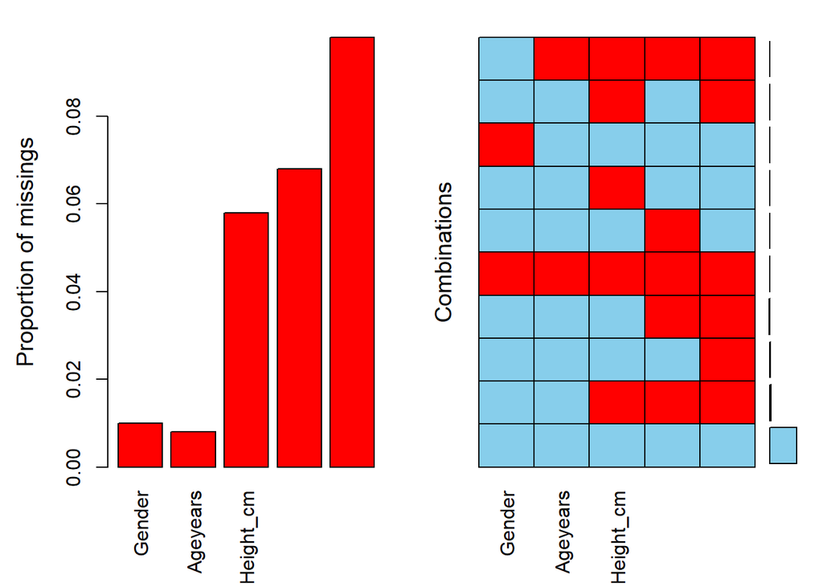

```r
library(mice)
library(VIM)
library(lattice)
#Dependent: height Exposure: Arm Length
#Variables that might help: Gender, ageyears, foot_length_cm
partc <- school2[,5:10]
partc <- partc[,-3]

aggr(partc)
```

```r
str(partc)
```

```
## Classes 'tbl_df', 'tbl' and 'data.frame':    500 obs. of  5 variables:
##  $ Gender       : chr  "Male" "Male" "Female" "Female" ...
##  $ Ageyears     : num  17 17 17 16 15 17 17 16 15 15 ...
##  $ Height_cm    : chr  "182" "185.6" "98" "160" ...
##  $ Footlength_cm: chr  "24" "27" "20" "23.8" ...
##  $ Armspan_cm   : chr  "186" "200" "120" "163" ...
```

```r
library(stringr)
colSums(is.na(partc))
```

```
##        Gender      Ageyears     Height_cm Footlength_cm    Armspan_cm
##             5             4            29            34            49
```

```r
numextract <- function(string){
  str_extract(string, "\\-*\\d+\\.*\\d*")
}

partc$Gender <- as.factor(partc$Gender)
partc$Height_cm <- as.numeric(numextract(partc$Height_cm))
partc$Footlength_cm <- as.numeric(numextract(partc$Footlength_cm))
partc$Armspan_cm <- as.numeric(numextract(partc$Armspan_cm))

colSums(is.na(partc))
```

```
##        Gender      Ageyears     Height_cm Footlength_cm    Armspan_cm
##             5             4            29            34            50
```

```r
#Because some people put their height in inches instead of centimeters, those must be removed.
summary(partc)
```

```
##     Gender       Ageyears       Height_cm       Footlength_cm
##  Female:274   Min.   :12.00   Min.   :    1.8   Min.   :   2.00
##  Male  :221   1st Qu.:15.00   1st Qu.:  160.0   1st Qu.:  23.00
##  NA's  :  5   Median :17.00   Median :  166.0   Median :  24.00
##               Mean   :16.36   Mean   :  371.3   Mean   :  31.27
##               3rd Qu.:17.00   3rd Qu.:  175.2   3rd Qu.:  26.00
##               Max.   :99.00   Max.   :99999.0   Max.   :2426.00
##               NA's   :4       NA's   :29        NA's   :34
##    Armspan_cm
##  Min.   :  1.88
##  1st Qu.:154.00
##  Median :164.00
##  Mean   :153.16
##  3rd Qu.:175.00
##  Max.   :431.80
##  NA's   :50
```

```r
partc$Ageyears[partc$Ageyears > 20] <- NA
partc$Height_cm[partc$Height_cm < 120] <- NA
partc$Height_cm[partc$Height_cm > 200] <- NA
partc$Footlength_cm[partc$Footlength_cm < 20] <- NA
partc$Footlength_cm[partc$Footlength_cm > 36] <- NA
partc$Armspan_cm[partc$Armspan_cm < 110] <- NA
partc$Armspan_cm[partc$Armspan_cm > 205] <- NA

colSums(is.na(partc))
```

```
##        Gender      Ageyears     Height_cm Footlength_cm    Armspan_cm
##             5             8            76            77           113
```

```r
# CART Model
library(norm)
imp_cart <- mice(partc, m=5, method='cart',seed=37, printFlag=FALSE)
impDatList_cart <- list()

impDatList_cart[[1]]<-complete(imp_cart,1)
impDatList_cart[[2]]<-complete(imp_cart,2)
impDatList_cart[[3]]<-complete(imp_cart,3)
impDatList_cart[[4]]<-complete(imp_cart,4)
impDatList_cart[[5]]<-complete(imp_cart,5)

summary(lm(Height_cm~Armspan_cm,data=as.data.frame(impDatList_cart[[1]])))
```

```
##
## Call:
## lm(formula = Height_cm ~ Armspan_cm, data = as.data.frame(impDatList_cart[[1]]))
##
## Residuals:
##      Min       1Q   Median       3Q      Max
## -25.8647  -3.7821  -0.1688   3.9851  24.6133
##
## Coefficients:
##             Estimate Std. Error t value Pr(>|t|)
## (Intercept) 65.56370    3.69783   17.73   <2e-16 ***
## Armspan_cm   0.61330    0.02204   27.82   <2e-16 ***
## ---
## Signif. codes:  0 '***' 0.001 '**' 0.01 '*' 0.05 '.' 0.1 ' ' 1
##
## Residual standard error: 6.82 on 498 degrees of freedom
## Multiple R-squared:  0.6085, Adjusted R-squared:  0.6078
## F-statistic: 774.2 on 1 and 498 DF,  p-value: < 2.2e-16
```

```r
summary(lm(Height_cm~Armspan_cm,data=as.data.frame(impDatList_cart[[2]])))
```

```
##
## Call:
## lm(formula = Height_cm ~ Armspan_cm, data = as.data.frame(impDatList_cart[[2]]))
##
## Residuals:
##      Min       1Q   Median       3Q      Max
## -31.4458  -3.8677  -0.0559   4.0830  24.5731
##
## Coefficients:
##             Estimate Std. Error t value Pr(>|t|)
## (Intercept) 65.74338    3.63828   18.07   <2e-16 ***
## Armspan_cm   0.61216    0.02174   28.16   <2e-16 ***
## ---
## Signif. codes:  0 '***' 0.001 '**' 0.01 '*' 0.05 '.' 0.1 ' ' 1
##
## Residual standard error: 7.012 on 498 degrees of freedom
## Multiple R-squared:  0.6142, Adjusted R-squared:  0.6134
## F-statistic: 792.9 on 1 and 498 DF,  p-value: < 2.2e-16
```

```r
summary(lm(Height_cm~Armspan_cm,data=as.data.frame(impDatList_cart[[3]])))
```

```
##
## Call:
## lm(formula = Height_cm ~ Armspan_cm, data = as.data.frame(impDatList_cart[[3]]))
##
## Residuals:
##      Min       1Q   Median       3Q      Max
## -26.1295  -3.8872  -0.2496   3.8120  24.3914
##
## Coefficients:
##             Estimate Std. Error t value Pr(>|t|)
## (Intercept) 65.89124    3.57819   18.41   <2e-16 ***
## Armspan_cm   0.61244    0.02133   28.71   <2e-16 ***
## ---
## Signif. codes:  0 '***' 0.001 '**' 0.01 '*' 0.05 '.' 0.1 ' ' 1
##
## Residual standard error: 6.698 on 498 degrees of freedom
## Multiple R-squared:  0.6234, Adjusted R-squared:  0.6226
## F-statistic: 824.3 on 1 and 498 DF,  p-value: < 2.2e-16
```

```r
summary(lm(Height_cm~Armspan_cm,data=as.data.frame(impDatList_cart[[4]])))
```

```
##
## Call:
## lm(formula = Height_cm ~ Armspan_cm, data = as.data.frame(impDatList_cart[[4]]))
##
## Residuals:
##      Min       1Q   Median       3Q      Max
## -25.7817  -4.1306  -0.3404   4.0686  23.9317
##
## Coefficients:
##             Estimate Std. Error t value Pr(>|t|)
## (Intercept) 67.65878    3.75047   18.04   <2e-16 ***
## Armspan_cm   0.60172    0.02237   26.90   <2e-16 ***
## ---
## Signif. codes:  0 '***' 0.001 '**' 0.01 '*' 0.05 '.' 0.1 ' ' 1
##
## Residual standard error: 7.073 on 498 degrees of freedom
## Multiple R-squared:  0.5923, Adjusted R-squared:  0.5915
## F-statistic: 723.4 on 1 and 498 DF,  p-value: < 2.2e-16
```

```r
summary(lm(Height_cm~Armspan_cm,data=as.data.frame(impDatList_cart[[5]])))
```

```
##
## Call:
## lm(formula = Height_cm ~ Armspan_cm, data = as.data.frame(impDatList_cart[[5]]))
##
## Residuals:
##      Min       1Q   Median       3Q      Max
## -26.5351  -3.8946  -0.3027   3.7402  25.4783
##
## Coefficients:
##             Estimate Std. Error t value Pr(>|t|)
## (Intercept) 61.86040    3.53208   17.51   <2e-16 ***
## Armspan_cm   0.63657    0.02106   30.23   <2e-16 ***
## ---
## Signif. codes:  0 '***' 0.001 '**' 0.01 '*' 0.05 '.' 0.1 ' ' 1
##
## Residual standard error: 6.553 on 498 degrees of freedom
## Multiple R-squared:  0.6472, Adjusted R-squared:  0.6465
## F-statistic: 913.5 on 1 and 498 DF,  p-value: < 2.2e-16
```

```r
betaList_cart<-seList_cart<-list()
for (i in 1:5){
betaList_cart[[i]]<-summary(lm(Height_cm~Armspan_cm,data=as.data.frame(impDatList_cart[[i]])))$coefficients[,1]
seList_cart[[i]]<-summary(lm(Height_cm~Armspan_cm,data=as.data.frame(impDatList_cart[[i]])))$coefficients[,2]
}

mi.inference(betaList_cart,seList_cart)$est
```

```
## (Intercept)  Armspan_cm
##  65.3434984   0.6152372
```

```r
mi.inference(betaList_cart,seList_cart)$std.err
```

```
## (Intercept)  Armspan_cm
##  4.31873857  0.02586827
```

```r
mi.inference(betaList_cart,seList_cart)$signif
```

```
## (Intercept)  Armspan_cm
##           0           0
```

For the CART model, it is determined that for ever on centimeter increase in armspan, the estimated height of of the person in centimeters goes up 0.6152 centimeters. The estimated standard error is 0.0259 and with a p-value of 0, armspan is statistically significant.

## Random Forest

```r
imp_rf <- mice(partc, m=5, method='rf',seed=85, printFlag=FALSE)

impDatList_rf <- list()
impDatList_rf[[1]]<-complete(imp_rf,1)
impDatList_rf[[2]]<-complete(imp_rf,2)
impDatList_rf[[3]]<-complete(imp_rf,3)
impDatList_rf[[4]]<-complete(imp_rf,4)
impDatList_rf[[5]]<-complete(imp_rf,5)

summary(lm(Height_cm~Armspan_cm,data=as.data.frame(impDatList_rf[[1]])))
```

```
##
## Call:
## lm(formula = Height_cm ~ Armspan_cm, data = as.data.frame(impDatList_rf[[1]]))
##
## Residuals:
##      Min       1Q   Median       3Q      Max
## -31.5229  -4.4346  -0.3135   4.6865  25.7225
##
## Coefficients:
##             Estimate Std. Error t value Pr(>|t|)
## (Intercept) 75.92190    4.09394   18.55   <2e-16 ***
## Armspan_cm   0.55180    0.02436   22.65   <2e-16 ***
## ---
## Signif. codes:  0 '***' 0.001 '**' 0.01 '*' 0.05 '.' 0.1 ' ' 1
##
## Residual standard error: 7.589 on 498 degrees of freedom
## Multiple R-squared:  0.5075, Adjusted R-squared:  0.5065
## F-statistic: 513.2 on 1 and 498 DF,  p-value: < 2.2e-16
```

```r
summary(lm(Height_cm~Armspan_cm,data=as.data.frame(impDatList_rf[[2]])))
```

```
##
## Call:
## lm(formula = Height_cm ~ Armspan_cm, data = as.data.frame(impDatList_rf[[2]]))
##
## Residuals:
##     Min      1Q  Median      3Q     Max
## -27.116  -4.886  -0.316   4.120  34.602
##
## Coefficients:
##             Estimate Std. Error t value Pr(>|t|)
## (Intercept) 82.67378    4.15582   19.89   <2e-16 ***
## Armspan_cm   0.51437    0.02479   20.75   <2e-16 ***
## ---
## Signif. codes:  0 '***' 0.001 '**' 0.01 '*' 0.05 '.' 0.1 ' ' 1
##
## Residual standard error: 7.965 on 498 degrees of freedom
## Multiple R-squared:  0.4636, Adjusted R-squared:  0.4625
## F-statistic: 430.4 on 1 and 498 DF,  p-value: < 2.2e-16
```

```r
summary(lm(Height_cm~Armspan_cm,data=as.data.frame(impDatList_rf[[3]])))
```

```
##
## Call:
## lm(formula = Height_cm ~ Armspan_cm, data = as.data.frame(impDatList_rf[[3]]))
##
## Residuals:
##     Min      1Q  Median      3Q     Max
## -32.474  -4.446   0.017   4.339  29.266
##
## Coefficients:
##             Estimate Std. Error t value Pr(>|t|)
## (Intercept) 78.57194    4.04566   19.42   <2e-16 ***
## Armspan_cm   0.53671    0.02407   22.30   <2e-16 ***
## ---
## Signif. codes:  0 '***' 0.001 '**' 0.01 '*' 0.05 '.' 0.1 ' ' 1
##
## Residual standard error: 7.595 on 498 degrees of freedom
## Multiple R-squared:  0.4995, Adjusted R-squared:  0.4985
## F-statistic: 497.1 on 1 and 498 DF,  p-value: < 2.2e-16
```

```r
summary(lm(Height_cm~Armspan_cm,data=as.data.frame(impDatList_rf[[4]])))
```

```
##
## Call:
## lm(formula = Height_cm ~ Armspan_cm, data = as.data.frame(impDatList_rf[[4]]))
##
## Residuals:
##     Min      1Q  Median      3Q     Max
## -38.568  -4.298  -0.305   4.654  24.204
##
## Coefficients:
##             Estimate Std. Error t value Pr(>|t|)
## (Intercept) 79.14007    4.06270   19.48   <2e-16 ***
## Armspan_cm   0.53214    0.02414   22.05   <2e-16 ***
## ---
## Signif. codes:  0 '***' 0.001 '**' 0.01 '*' 0.05 '.' 0.1 ' ' 1
##
## Residual standard error: 7.593 on 498 degrees of freedom
## Multiple R-squared:  0.4939, Adjusted R-squared:  0.4929
## F-statistic:   486 on 1 and 498 DF,  p-value: < 2.2e-16
```

```r
summary(lm(Height_cm~Armspan_cm,data=as.data.frame(impDatList_rf[[5]])))
```

```
##
## Call:
## lm(formula = Height_cm ~ Armspan_cm, data = as.data.frame(impDatList_rf[[5]]))
##
## Residuals:
##     Min      1Q  Median      3Q     Max
## -25.175  -5.066  -0.468   4.427  41.825
##
## Coefficients:
##             Estimate Std. Error t value Pr(>|t|)
## (Intercept) 85.39136    4.14072   20.62   <2e-16 ***
## Armspan_cm   0.49819    0.02463   20.23   <2e-16 ***
## ---
## Signif. codes:  0 '***' 0.001 '**' 0.01 '*' 0.05 '.' 0.1 ' ' 1
##
## Residual standard error: 8.032 on 498 degrees of freedom
## Multiple R-squared:  0.451,  Adjusted R-squared:  0.4499
## F-statistic: 409.1 on 1 and 498 DF,  p-value: < 2.2e-16
```

```r
betaList_rf<-seList_rf<-list()
for (i in 1:5){
betaList_rf[[i]]<-summary(lm(Height_cm~Armspan_cm,data=as.data.frame(impDatList_rf[[i]])))$coefficients[,1]
seList_rf[[i]]<-summary(lm(Height_cm~Armspan_cm,data=as.data.frame(impDatList_rf[[i]])))$coefficients[,2]
}

mi.inference(betaList_rf,seList_rf)$est
```

```
## (Intercept)  Armspan_cm
##  80.3398095   0.5266422
```

```r
mi.inference(betaList_rf,seList_rf)$std.err
```

```
## (Intercept)  Armspan_cm
##  5.77273029  0.03335829
```

```r
mi.inference(betaList_rf,seList_rf)$signif
```

```
##  (Intercept)   Armspan_cm
## 1.831504e-10 3.462786e-12
```

For the Random Forest model, it is determined that for ever on centimeter increase in armspan, the estimated height of of the person in centimeters goes up 0.5266 centimeters. The estimated standard error is 0.03336 and with a p-value of 3.462786e-12, armspan is statistically significant in this model.

## Github Link

Find my assignment at: https://github.com/bcristoff78/homework